# 5. Linking word knowledge to trial accuracy: settings × models

peekbank-items

**This notebook expands notebook 4.** Notebook 4 asked, at the *word-aggregate* level, whether harder words are recognized worse (the “does item difficulty line up” question). Here we move to the **trial** level and ask the predictive question directly: does a child’s knowledge of the specific target/distractor on a trial predict their looking on *that* trial? And we do it in a common framework that lets us vary two things:

- **how knowledge is measured** — three *data settings* (the aggregate setting here is exactly notebook 4’s idea, now at trial level);
- **the functional form of the link** — four nested *models* (H0–H3).

Ingredients come from earlier notebooks: LWL trial data (notebook 1), CDI word difficulty + child ability (notebook 3). The precise within-child story is developed fully in **notebook 6**; here it is one of the three settings.

The outline is: **(1)** the settings, **(2)** how much data each has, **(3)** the models, then the fits three ways — **(4)** coefficients, **(5)** model comparison, **(6)** out-of-sample prediction against the noise ceiling.

```r
library(here)
library(lme4)
source(here("helper", "common.R"))
knitr::opts_chunk$set(cache = FALSE)

d_trial <- readRDS(here("cached_intermediates", "1_d_trial.Rds")) |> ungroup()
d_sub   <- readRDS(here("cached_intermediates", "1_d_sub.Rds"))
cdi     <- readRDS(here("cached_intermediates", "3_cdi_difficulty.Rds"))
subset_dat  <- readRDS(here("cached_intermediates", "0_cdi_items_subset.Rds"))
subject_map <- readRDS(here("cached_intermediates", "0_subject_map.Rds"))
animates    <- readRDS(here("cached_intermediates", "2_lwl_item.Rds"))$animates

p2pl <- function(theta, a, b) plogis(a * (theta - b))
```

# 1. The three settings (ways to measure word knowledge)

For each trial we build a **target-knowledge** signal `k_t` and a **distractor-knowledge** signal `k_d`, always oriented so larger = more knowledge. The settings differ only in where that knowledge comes from:

| setting | `k_t`, `k_d` | child-specific? | item-specific? | from |
| --- | --- | --- | --- | --- |
| **aggregate** | `-b` (IRT *ease* of the word) | no | yes | notebook 3; = notebook 4 at trial level |
| **imputed** | `P(knows) = 2PL(θ_child, a, b)` | yes (CDI total) | only through difficulty | notebooks 1 + 3 |
| **precise** | child *actually produced* the word (0/1) | yes | yes (real) | item-level CDI (TotLot subset) |

```r
cdi_diff <- cdi$item_pars |> select(item, a, b)

base <- d_trial |>
  rename(accuracy = long_window_accuracy, elogit = long_window_elogit) |>
  filter(!is.na(elogit)) |>
  mutate(log_age = log(age), log_age_centered = log_age - mean(log_age),
         animate_target = target_label %in% animates,
         animate_distractor = distractor_label %in% animates) |>
  left_join(cdi_diff |> rename(a_t = a, b_t = b), by = c("target_label" = "item")) |>
  left_join(cdi_diff |> rename(a_d = a, b_d = b), by = c("distractor_label" = "item")) |>
  left_join(d_sub |> select(administration_id, prod), by = "administration_id") |>
  mutate(theta = cdi$prop_to_theta(prod),
         agg_k_t = -b_t, agg_k_d = -b_d,
         imp_k_t = p2pl(theta, a_t, b_t), imp_k_d = p2pl(theta, a_d, b_d))
```

```r
items_long <- subset_dat$cdi_items_long |>
  mutate(item = str_to_lower(item), lab_subject_id = as.character(lab_subject_id)) |>
  rename(cdi_age = age)
admins <- base |>
  distinct(administration_id, subject_id, age) |>
  inner_join(subject_map, by = "subject_id") |>
  filter(lab_subject_id %in% items_long$lab_subject_id)
nearest_cdi <- admins |>
  inner_join(items_long |> distinct(lab_subject_id, cdi_age),
             by = "lab_subject_id", relationship = "many-to-many") |>
  mutate(age_diff = abs(age - cdi_age)) |>
  group_by(administration_id) |> slice_min(age_diff, n = 1, with_ties = FALSE) |>
  ungroup() |> select(administration_id, lab_subject_id, cdi_age)
produces_at_age <- items_long |>
  group_by(lab_subject_id, cdi_age, item) |>
  summarise(produces = as.integer(any(produces == 1)), .groups = "drop")
precise <- base |>
  inner_join(nearest_cdi, by = "administration_id") |>
  left_join(produces_at_age |> rename(prec_k_t = produces),
            by = c("lab_subject_id", "cdi_age", "target_label" = "item")) |>
  left_join(produces_at_age |> rename(prec_k_d = produces),
            by = c("lab_subject_id", "cdi_age", "distractor_label" = "item")) |>
  filter(!is.na(prec_k_t), !is.na(prec_k_d))

# the analysis frame for each setting (its MAXIMAL usable data)
frames <- list(
  aggregate = base |> filter(!is.na(agg_k_t), !is.na(agg_k_d)) |>
    mutate(k_t = agg_k_t, k_d = agg_k_d),
  imputed   = base |> filter(!is.na(imp_k_t), !is.na(imp_k_d)) |>
    mutate(k_t = imp_k_t, k_d = imp_k_d),
  precise   = precise |> mutate(k_t = prec_k_t, k_d = prec_k_d)
)
```

# 2. How much data does each setting have?

A key design choice: we fit each setting on its **own maximal data**, not on a shared common subset. Crucially, the three settings draw on **different slices of the database**:

- **aggregate** needs only a word-difficulty estimate, so it uses *every* English trial — all 26 datasets.
- **imputed** needs a child’s CDI *summary* score, so it uses the (still large) set of children with any CDI.
- **precise** needs *item-level* CDI, which exists only for the Stanford TotLot cohort — **229 children** in 3 datasets. Its trial count is nonetheless sizable because those children are **longitudinal** (~6.5 sessions each, many trials per session).

So the big numbers below are *trials* and *administrations* (LWL sessions), not unique children — note the separate `children` column. Forcing all three onto a common subset would throw away the scale of aggregate/imputed and restrict everything to TotLot; we show that controlled check at the end instead.

```r
imap_dfr(frames, ~ tibble(
  setting = .y,
  trials = nrow(.x),
  administrations = n_distinct(.x$administration_id),
  children = n_distinct(.x$subject_id),
  datasets = n_distinct(.x$dataset_name),
  target_words = n_distinct(.x$target_label),
  age = sprintf("%.0f–%.0f", min(.x$age), max(.x$age)),
  longitudinal = ifelse(.y == "precise", "yes (~6.5 sessions/child)", "cross-sectional")
)) |> kable(caption = "Maximal usable data per setting (note: trials/administrations ≫ children)")
```

Maximal usable data per setting (note: trials/administrations ≫ children)

| setting | trials | administrations | children | datasets | target_words | age | longitudinal |
| --- | --- | --- | --- | --- | --- | --- | --- |
| aggregate | 49844 | 4082 | 2514 | 26 | 111 | 6–60 | cross-sectional |
| imputed | 30390 | 1839 | 777 | 14 | 79 | 6–32 | cross-sectional |
| precise | 25850 | 1489 | 229 | 3 | 22 | 13–38 | yes (~6.5 sessions/child) |

# 3. The four models

Every model shares the same random structure — a child intercept `u_c` (absorbing general ability) and a dataset intercept `v_s` — and differs only in how knowledge enters:

$$\textbf{H0:}\quad \text{elogit} = \beta_0 + \beta_{age}\log\text{age} + \beta_{anim}\text{animacy} + u_c + v_s + \varepsilon$$
$$\textbf{H1:}\quad \ldots + \beta_t\,k_t \qquad\text{(target only)} \qquad
\textbf{H2:}\quad \ldots + \beta_t\,k_t + \beta_d\,k_d \qquad\text{(target + distractor)}$$
$$\textbf{H3:}\quad \ldots + \beta_\Delta\,(k_t - k_d) \qquad\text{(symmetric 2AFC contrast)}$$

Inferences: **H1 vs H0** = does target knowledge help (`β_t>0`)? **H2 vs H1** = does the distractor add anything (`β_d<0` if a known competitor steals looks)? **H3** forces target and distractor to count equally and oppositely — if the link is asymmetric, H3 fits *worse* than H2 despite being the “tidy” story.

Note: these models contain a child intercept but **no word intercept**, so a knowledge coefficient is allowed to ride on between-word difficulty. That is the right choice for “does knowledge predict looking at all,” and it is the bridge to notebook 6, which adds word intercepts to isolate the purely *item-specific* part.

All models also include **animacy** fixed effects (`animate_target`, `animate_distractor`) in the shared baseline. Animacy is a perceptual-salience confound that mattered a lot in notebook 4, so we control it here too — though as it turns out it barely moves the knowledge coefficients (the settings already carry word identity). (Notebook 6 needs no animacy term: its *word* random intercepts absorb animacy completely, since animacy is a property of the word.)

```r
baseline <- c("log_age_centered", "animate_target", "animate_distractor")
fit_model <- function(d, terms) {
  fixed <- paste(c(baseline, terms), collapse = " + ")
  lmer(as.formula(paste0("elogit ~ ", fixed, " + (1|administration_id) + (1|dataset_name)")),
       data = d, control = lmerControl(optimizer = "bobyqa"))
}
model_terms <- list(H0 = character(0), H1 = "k_t", H2 = c("k_t", "k_d"),
                    H3 = "I(k_t - k_d)")
```

# 4. The fits, directly: knowledge coefficients

We fit H2 in each setting (on its maximal data) and plot the target and distractor coefficients with 95% CIs. To make settings comparable despite their different scales (`-b` in logits, a probability, a 0/1 indicator), predictors are **standardized to SD = 1**, so each coefficient is “elogit change per 1 SD of the knowledge measure.” Expected: **target positive, distractor negative**.

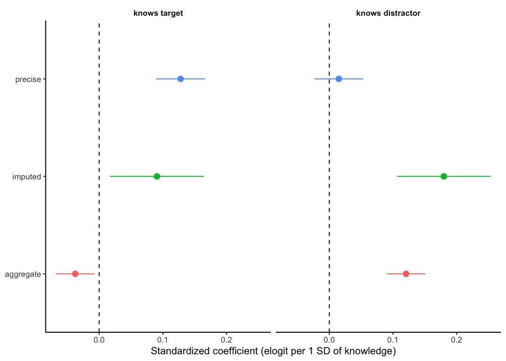

```r
coef_h2 <- imap_dfr(frames, function(d, setting) {
  d <- d |> mutate(k_t = as.numeric(scale(k_t)), k_d = as.numeric(scale(k_d)))
  m <- fit_model(d, c("k_t", "k_d"))
  ci <- confint(m, parm = c("k_t", "k_d"), method = "Wald")
  tibble(setting = setting,
         term = c("knows target", "knows distractor"),
         beta = fixef(m)[c("k_t", "k_d")], lo = ci[, 1], hi = ci[, 2])
})
coef_h2 <- coef_h2 |>
  mutate(term = factor(term, levels = c("knows target", "knows distractor")))

ggplot(coef_h2, aes(x = beta, y = setting, color = setting)) +
  geom_vline(xintercept = 0, lty = 2) +
  geom_pointrange(aes(xmin = lo, xmax = hi)) +
  facet_wrap(~term) +
  xlab("Standardized coefficient (elogit per 1 SD of knowledge)") +
  ylab(NULL) + theme(legend.position = "none")
```

What this shows:

- **aggregate** — the target coefficient is ~0/negative: *word ease does not predict higher trial accuracy*. This is the **trial-level replication of the naive failure** from notebook 4 (and the distractor term is wrong-signed too — the confounds that bedevil the aggregate level are fully present here).
- **imputed** — *both* coefficients are positive. Because `P(knows target)` and `P(knows distractor)` are both driven by the same child ability `θ`, they largely re-express the child-ability main effect and cannot be separated; the distractor “helping” is the giveaway.
- **precise** — a clean, **asymmetric** result: knowing the *target* helps, knowing the *distractor* does essentially nothing. Only real item-level CDI yields the interpretable picture.

# 5. Which functional form? (model comparison)

For each setting we compare H0–H3 by AIC (lower = better; nested H0→H1→H2 also get likelihood-ratio tests). This is the “do we see the fits” view.

```r
compare <- imap_dfr(frames, function(d, setting) {
  ms <- lapply(model_terms, fit_model, d = d)
  tibble(setting = setting, model = names(ms),
         AIC = sapply(ms, AIC)) |>
    mutate(dAIC = AIC - AIC[model == "H0"])
})
compare |>
  select(setting, model, dAIC) |>
  pivot_wider(names_from = model, values_from = dAIC) |>
  kable(digits = 1, caption = "ΔAIC vs H0 (more negative = better). H3 is the symmetric-contrast model.")
```

ΔAIC vs H0 (more negative = better). H3 is the symmetric-contrast model.

| setting | H0 | H1 | H2 | H3 |
| --- | --- | --- | --- | --- |
| aggregate | 0 | 7.4 | -46.3 | -30.1 |
| imputed | 0 | -84.5 | -102.8 | 3.1 |
| precise | 0 | -42.2 | -36.3 | -6.1 |

Read the rows: a large negative ΔAIC at H1 means target knowledge helps; H2 close to H1 means the distractor adds little; **H3 worse than H2** confirms the link is not the symmetric contrast. (In the precise setting the asymmetry is starkest — exactly what notebook 6 dissects.)

# 6. Out-of-sample prediction, against the noise ceiling

A single trial is mostly irreducible noise, so absolute R² *must* be small. We first measure the ceiling — the share of trial-elogit variance that is **not** residual noise (i.e., the most any fixed-effect model could explain) — then report each model’s child-grouped 5-fold CV R² as a fraction of that ceiling.

```r
ceiling_of <- function(d) {
  m <- fit_model(d, character(0))
  vc <- as.data.frame(VarCorr(m))
  1 - vc$vcov[vc$grp == "Residual"] / sum(vc$vcov)
}
ceilings <- map_dbl(frames, ceiling_of)
tibble(setting = names(ceilings), explainable_ceiling = ceilings) |>
  kable(digits = 3, caption = "Explainable share of trial variance (R² ceiling)")
```

Explainable share of trial variance (R² ceiling)

| setting | explainable_ceiling |
| --- | --- |
| aggregate | 0.055 |
| imputed | 0.046 |
| precise | 0.052 |

```r
set.seed(42)
cv_r2 <- function(d, terms, n_folds = 5) {
  fixed <- paste(c(baseline, terms), collapse = " + ")
  form <- as.formula(paste0("elogit ~ ", fixed,
                            " + (1|administration_id) + (1|dataset_name)"))
  subs <- unique(d$administration_id)
  fold <- setNames(sample(rep(1:n_folds, length.out = length(subs))), subs)
  d$.fold <- fold[as.character(d$administration_id)]
  preds <- rep(NA_real_, nrow(d))
  for (f in 1:n_folds) {
    tr <- d |> filter(.fold != f); te <- which(d$.fold == f)
    m <- tryCatch(lmer(form, data = tr, control = lmerControl(optimizer = "bobyqa")),
                  error = function(e) NULL)
    if (!is.null(m)) preds[te] <- predict(m, newdata = d[te, ], re.form = NA, allow.new.levels = TRUE)
  }
  ok <- !is.na(preds); if (sum(ok) < 10) return(NA_real_)
  cor(preds[ok], d$elogit[ok])^2
}

cv_tab <- imap_dfr(frames, function(d, setting) {
  cei <- ceilings[[setting]]
  r2 <- map_dbl(model_terms, ~ cv_r2(d, .x))
  tibble(setting = setting, model = names(model_terms),
         cv_r2 = r2, pct_of_ceiling = 100 * r2 / cei)
})
cv_tab |>
  select(setting, model, pct_of_ceiling) |>
  pivot_wider(names_from = model, values_from = pct_of_ceiling) |>
  kable(digits = 0, caption = "CV R² as % of the explainable ceiling (100% = all explainable variance captured)")
```

CV R² as % of the explainable ceiling (100% = all explainable variance captured)

| setting | H0 | H1 | H2 | H3 |
| --- | --- | --- | --- | --- |
| aggregate | 55 | 55 | 58 | 56 |
| imputed | 64 | 75 | 77 | 64 |
| precise | 61 | 66 | 66 | 62 |

Normalized this way the raw “tiny” R² disappears: age alone (H0) already captures ~half to two-thirds of the *explainable* variance, and adding knowledge pushes it higher — most for **imputed** (because `P(knows)` carries the child’s overall ability, which is what best predicts a *new* child’s trials), less for precise and aggregate. Note the contrast with §4: precise gives the cleanest *item-level estimate*, but imputed *predicts new children* best because it is ability-laden. Explanation and out-of-sample prediction reward different signals here.

# 7. Controlled check: all settings on the same trials

For completeness, the same comparison restricted to the precise subset’s trials (so all three settings describe identical rows). This is lower-powered and age-restricted; it makes the aggregate failure look worse and inflates the imputed CIs — which is exactly why §4–6 use each setting’s maximal data.

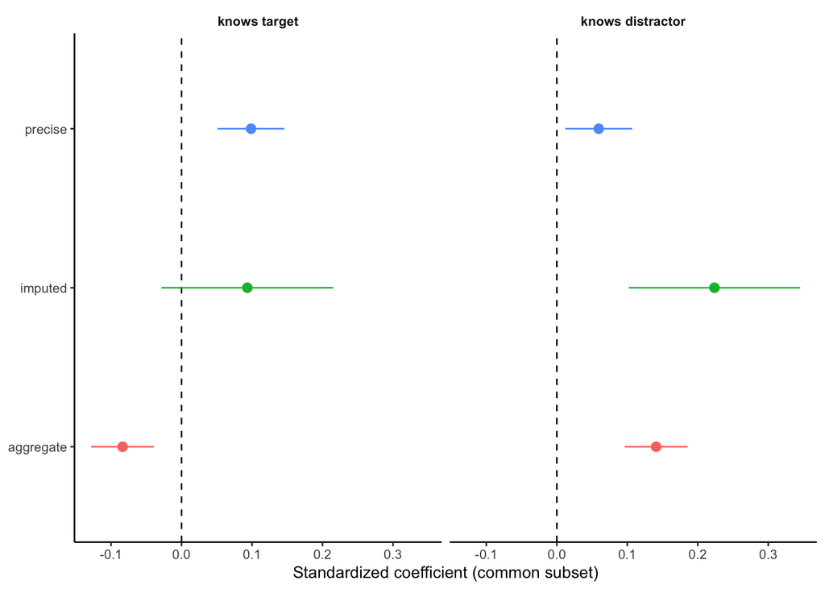

```r
common <- precise |>
  filter(!is.na(agg_k_t), !is.na(agg_k_d), !is.na(imp_k_t), !is.na(imp_k_d))
z <- function(x) as.numeric(scale(x))
common_coef <- bind_rows(
  aggregate = mutate(common, k_t = z(agg_k_t), k_d = z(agg_k_d)),
  imputed   = mutate(common, k_t = z(imp_k_t), k_d = z(imp_k_d)),
  precise   = mutate(common, k_t = z(prec_k_t), k_d = z(prec_k_d)),
  .id = "setting"
) |>
  group_by(setting) |>
  group_modify(~{
    m <- fit_model(.x, c("k_t", "k_d")); ci <- confint(m, c("k_t","k_d"), method = "Wald")
    tibble(term = c("knows target","knows distractor"),
           beta = fixef(m)[c("k_t","k_d")], lo = ci[,1], hi = ci[,2])
  }) |> ungroup() |>
  mutate(term = factor(term, levels = c("knows target", "knows distractor")))

ggplot(common_coef, aes(x = beta, y = setting, color = setting)) +
  geom_vline(xintercept = 0, lty = 2) +
  geom_pointrange(aes(xmin = lo, xmax = hi)) +
  facet_wrap(~term) +
  xlab("Standardized coefficient (common subset)") + ylab(NULL) +
  theme(legend.position = "none")
```

# Conclusions

- **Word knowledge predicts trial looking, but only when measured child- and item-specifically.** The aggregate setting (= notebook 4 at trial level) fails again; imputation adds child ability but can’t separate target from distractor; the precise setting gives a clean signal.
- **The link is asymmetric** — target knowledge drives it, the distractor does not — so the symmetric 2AFC contrast (H3) is the wrong model (H3 > H2 in AIC).
- **The small R² is a noise-floor artifact**: against the ~5% explainable ceiling, the good models capture most of what is explainable.
- This motivates **notebook 6**, which removes word difficulty entirely (word random intercepts) and uses the subset’s longitudinal structure to test the strict, item-specific, within-child linkage.